# Relatório

Igor Isidoro

09/08/2022

## Idade

Amplitude

```
## [1] 52
```

Média

```
## [1] 33.6
```

Quartis 1, 2 e 3 respectivamente

```
## 25%
##  25
```

```
## 50%
##  28
```

```
##  75%
## 39.5
```

Frequência absoluta, relativa e percentual respectivamente

```
## rolIdades
## 18 20 21 25 27 29 30 31 34 38 44 45 60 70
##  2  1  1  4  2  1  1  1  1  1  1  1  2  1
```

```
## rolIdades
##   18   20   21   25   27   29   30   31   34   38   44   45   60   70
## 0.10 0.05 0.05 0.20 0.10 0.05 0.05 0.05 0.05 0.05 0.05 0.05 0.10 0.05
```

```
## rolIdades
## 18 20 21 25 27 29 30 31 34 38 44 45 60 70
## 10  5  5 20 10  5  5  5  5  5  5  5 10  5
```

Variância e Desvio Padrão respectivamente

```
## [1] 222.6737
```

```
## [1] 14.92225
```

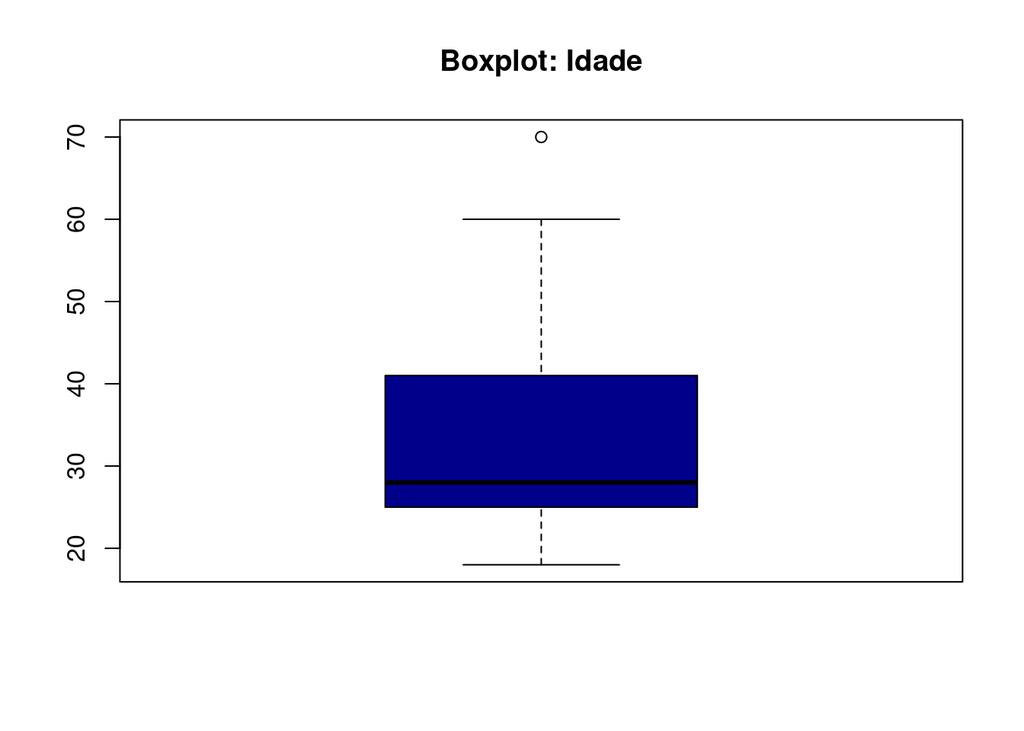

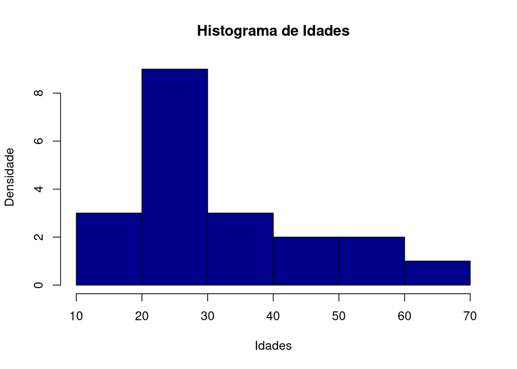

- Dados mais concentrados no intervalo de [20, 30]
- 65% dos dados se encontram abaixo da média
- Conjunto não uniforme

## Sexo

Frequência absoluta, relativa e percentual respectivamente

```
##
##  Feminino       Masculino
##              9             11
```

```
##
##  Feminino       Masculino
##           0.45           0.55
```

```
##
##  Feminino       Masculino
##             45             55
```

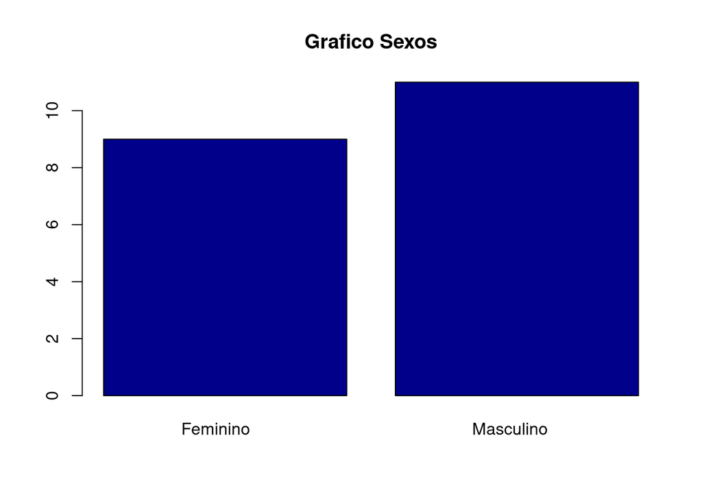

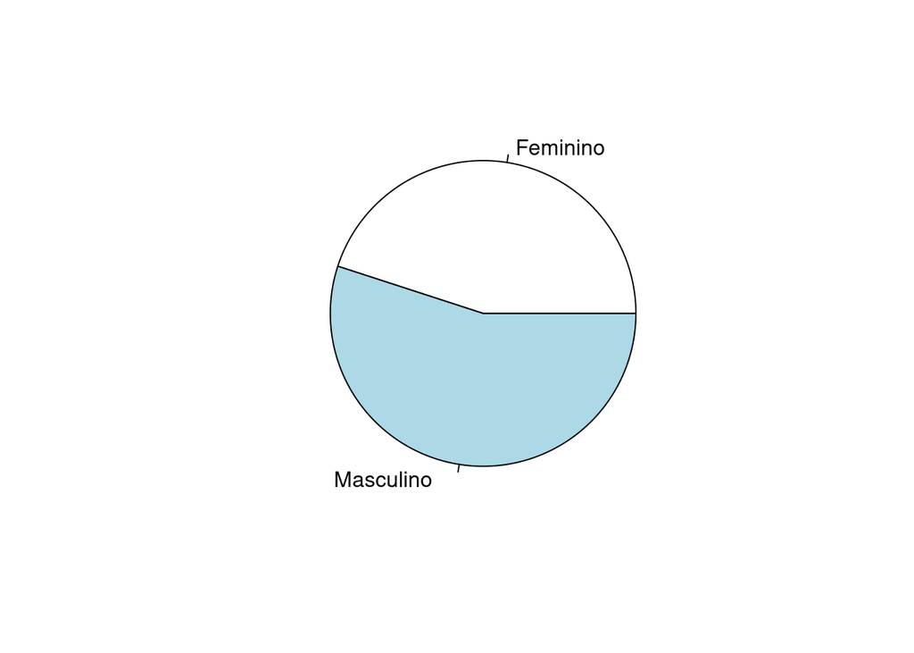

- Número de pessoas do sexo masculino e feminino se encontra equiparado

## Raça

Frequência absoluta, relativa e percentual respectivamente

```
##
##  Amarelo    Branco     Indigena   Pardo      Preto
##          4          5          4          5          2
```

```
##
##  Amarelo    Branco     Indigena   Pardo      Preto
##       0.20       0.25       0.20       0.25       0.10
```

```
##
##  Amarelo    Branco     Indigena   Pardo      Preto
##         20         25         20         25         10
```

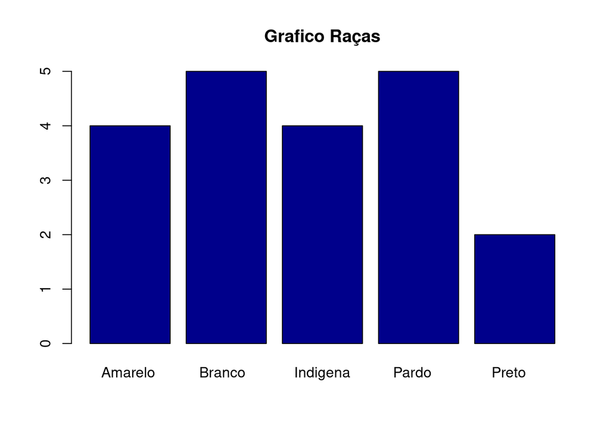

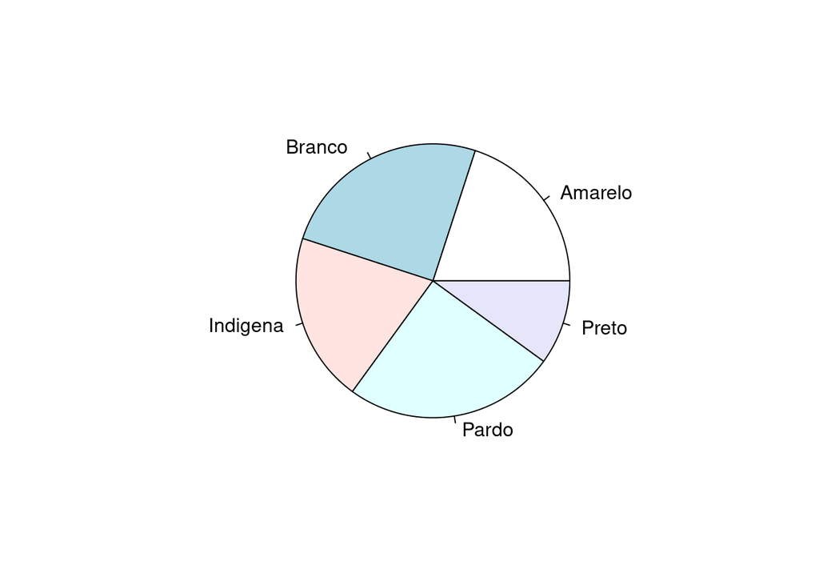

- Conjunto uniforme de dados, com exceção da raça “Preto” que houve um menor número de pessoas em relação ao número de pessoas das demais raças

## Escolaridade

Frequência absoluta, relativa e percentual respectivamente

```
##
##  Ensino Medio Completo            Ensino Medio Incompleto
##                                7                                1
##  Ensino Superior Completo         Ensino Superior Incompleto
##                                4                                8
```

```
##
##  Ensino Medio Completo            Ensino Medio Incompleto
##                             0.35                             0.05
##  Ensino Superior Completo         Ensino Superior Incompleto
##                             0.20                             0.40
```

```
##
##  Ensino Medio Completo            Ensino Medio Incompleto
##                               35                                5
##  Ensino Superior Completo         Ensino Superior Incompleto
##                               20                               40
```

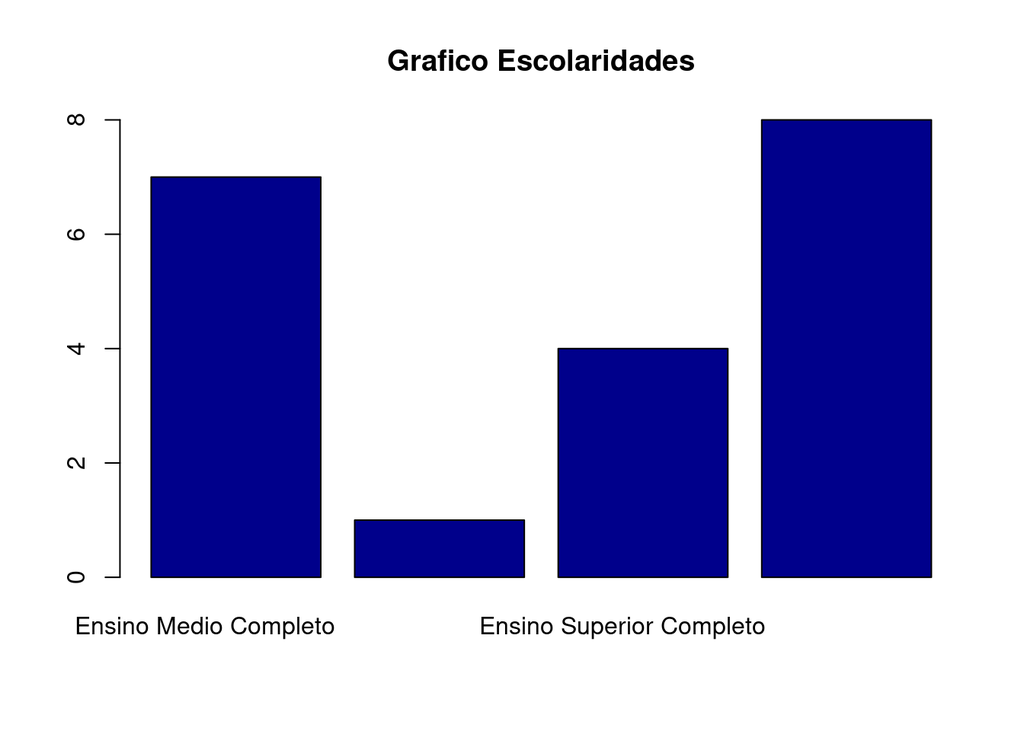

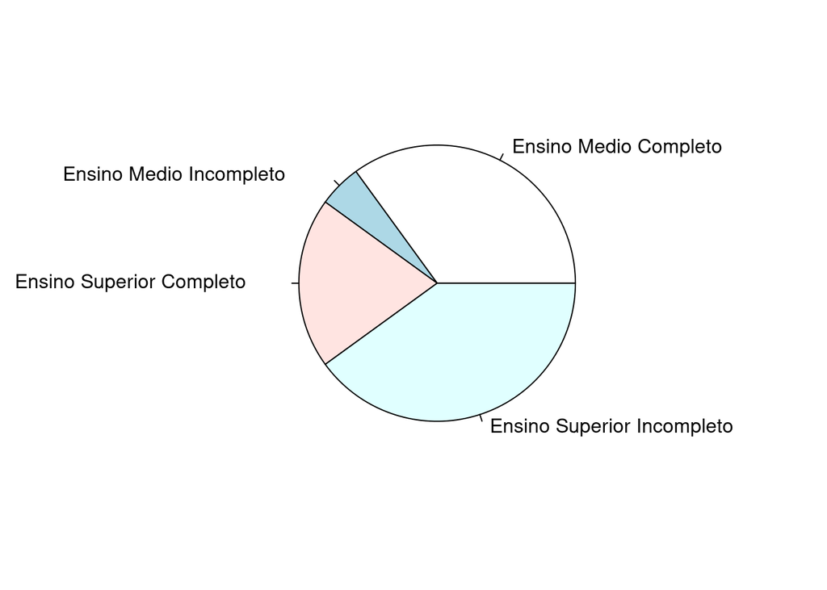

- 60% das pessoas que realizaram a pesquisa já cursaram ou se encontram cursando uma universidade

## Profissão

Frequência absoluta, relativa e percentual respectivamente

```
##
##  advogada               aposentada             desempregada
##                      1                      1                      1
##  desempregado           desenvolvedor          designer
##                      1                      1                      3
##  eletricista            empresario             enfermeira
##                      1                      1                      1
##  faxineira              jogador de futebol     marceneiro
##                      1                      1                      1
##  motorista              professor              recepcionista
##                      1                      1                      1
##  reporter               servidor publico       vendedor
##                      1                      1                      1
```

```
##
##  advogada               aposentada             desempregada
##                   0.05                   0.05                   0.05
##  desempregado           desenvolvedor          designer
##                   0.05                   0.05                   0.15
##  eletricista            empresario             enfermeira
##                   0.05                   0.05                   0.05
##  faxineira              jogador de futebol     marceneiro
##                   0.05                   0.05                   0.05
##  motorista              professor              recepcionista
##                   0.05                   0.05                   0.05
##  reporter               servidor publico       vendedor
##                   0.05                   0.05                   0.05
```

```
##
##  advogada               aposentada             desempregada
##                      5                      5                      5
##  desempregado           desenvolvedor          designer
##                      5                      5                     15
##  eletricista            empresario             enfermeira
##                      5                      5                      5
##  faxineira              jogador de futebol     marceneiro
##                      5                      5                      5
##  motorista              professor              recepcionista
##                      5                      5                      5
##  reporter               servidor publico       vendedor
##                      5                      5                      5
```

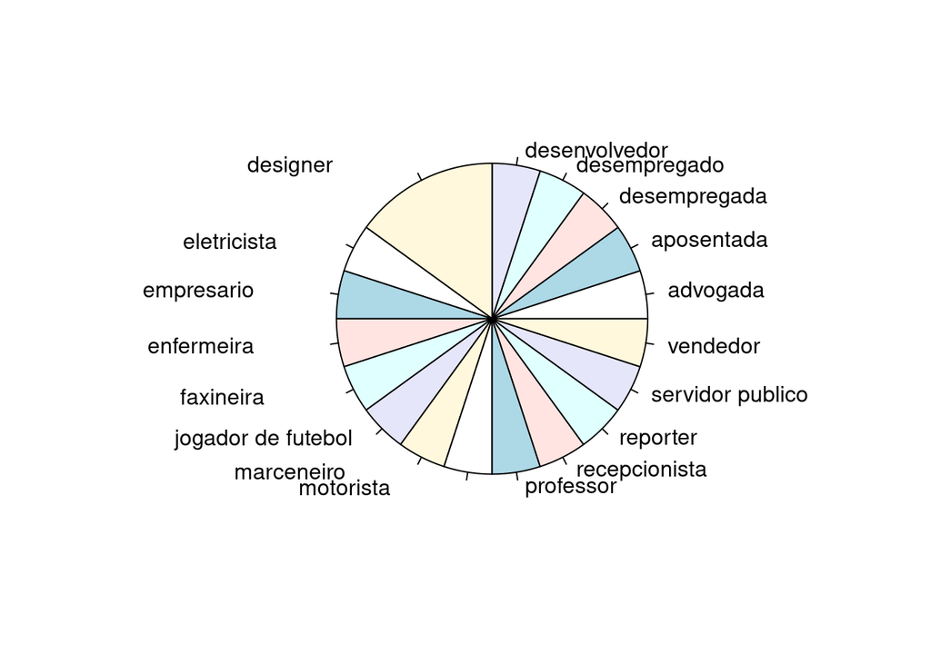

- Conjunto uniforme de dados, com exceção de designer e desempregado(a) que se destacaram dos demais

## Salario

Amplitude

```
## [1] 25000
```

Média

```
## [1] 4152.775
```

Quartis 1, 2 e 3 respectivamente

```
##  25%
## 1725
```

```
##     50%
## 2200.25
```

```
##      75%
## 3500.675
```

Frequência absoluta, relativa e percentual respectivamente

```
## rolSalarios
##      0   1050 1400.5   1500   1800 2000.4   2200 2200.5 2350.7 2450.5 2700.9
##      2      1      1      1      1      2      2      1      1      1      1
## 3000.9   5000 5000.3 6200.4  15000  25000
##      1      1      1      1      1      1
```

```
## rolSalarios
##      0   1050 1400.5   1500   1800 2000.4   2200 2200.5 2350.7 2450.5 2700.9
##   0.10   0.05   0.05   0.05   0.05   0.10   0.10   0.05   0.05   0.05   0.05
## 3000.9   5000 5000.3 6200.4  15000  25000
##   0.05   0.05   0.05   0.05   0.05   0.05
```

```
## rolSalarios
##      0   1050 1400.5   1500   1800 2000.4   2200 2200.5 2350.7 2450.5 2700.9
##     10      5      5      5      5     10     10      5      5      5      5
## 3000.9   5000 5000.3 6200.4  15000  25000
##      5      5      5      5      5      5
```

Variância e Desvio Padrão respectivamente

```
## [1] 34339340
```

```
## [1] 5859.978
```

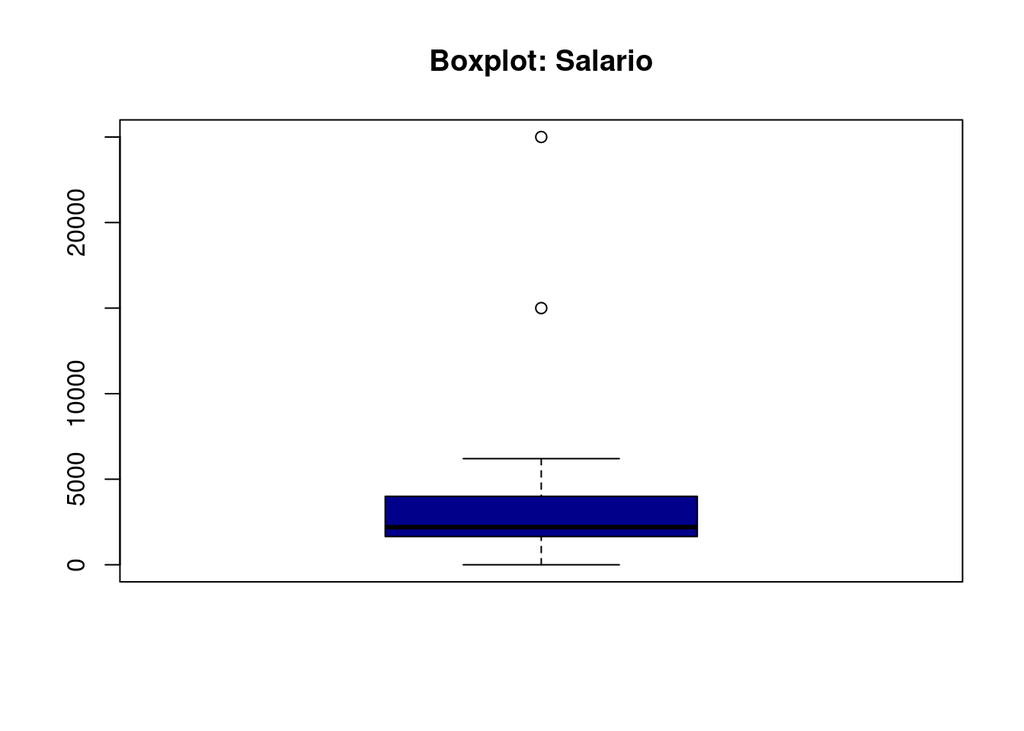

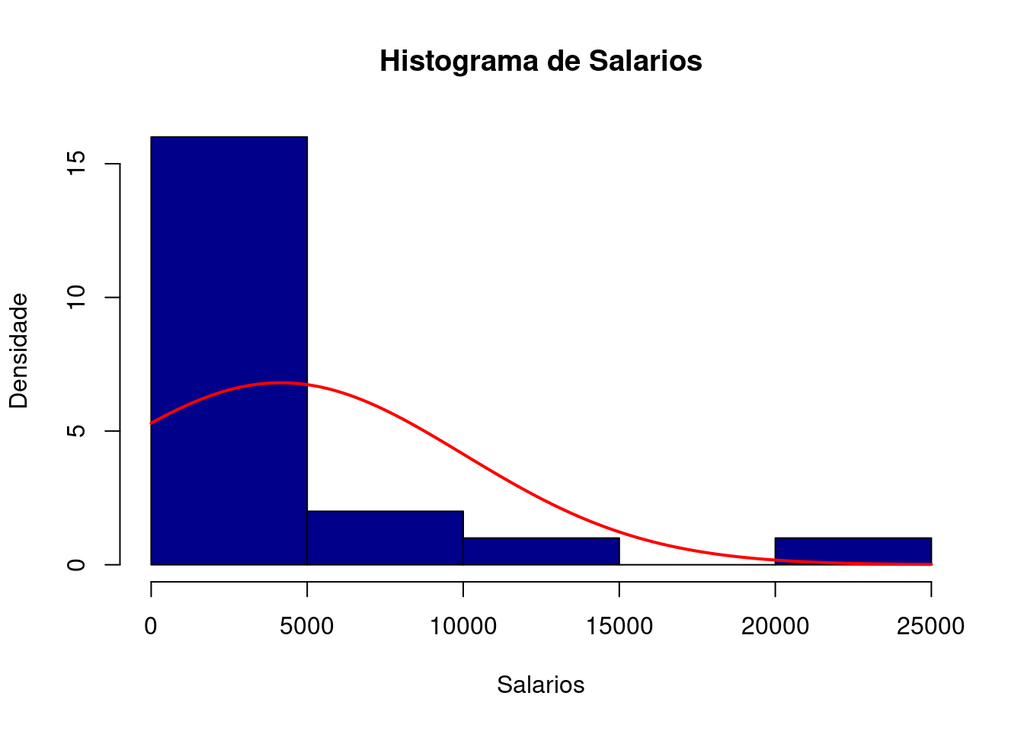

- Pode-se notar que a maior parte dos entrevistados possui um salário entre 0 e 5000.00 reais, porém houveram 2 ouliers sendo um com salário de 15000.00 reais e outro com salário de 25000.00 reais

## Número de Viagens ao exterior

Amplitude

```
## [1] 7
```

Média

```
## [1] 1.05
```

Quartis 1, 2 e 3 respectivamente

```
## 25%
##   0
```

```
## 50%
##   0
```

```
##  75%
## 1.25
```

Frequência absoluta, relativa e percentual respectivamente

```
## rolNumViagens
##  0  1  2  3  4  7
## 12  3  2  1  1  1
```

```
## rolNumViagens
##    0    1    2    3    4    7
## 0.60 0.15 0.10 0.05 0.05 0.05
```

```
## rolNumViagens
##  0  1  2  3  4  7
## 60 15 10  5  5  5
```

Variância e Desvio Padrão respectivamente

```
## [1] 3.313158
```

```
## [1] 1.820208
```

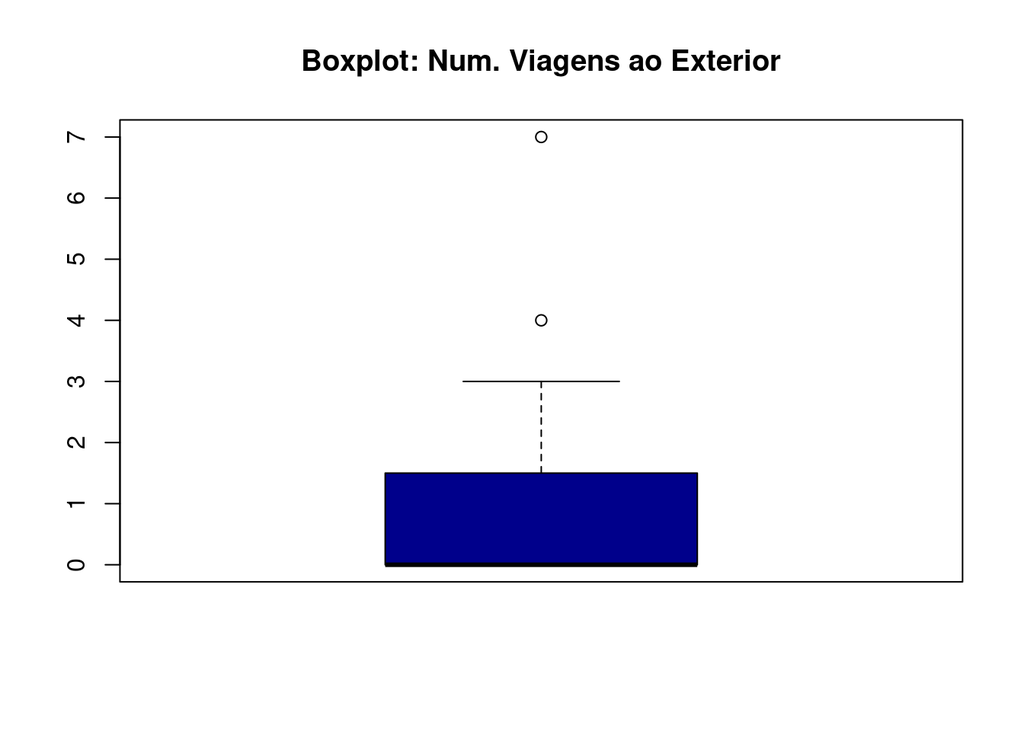

- 60% das pessoas nunca viajaram para o exterior, porém foram notados 2 outliers, sendo um com 4 viagens e outro com 7.

## Número de Filhos

Amplitude

```
## [1] 5
```

Média

```
## [1] 1.2
```

Quartis 1, 2 e 3 respectivamente

```
## 25%
##   0
```

```
## 50%
##   1
```

```
## 75%
##   2
```

Frequência absoluta, relativa e percentual respectivamente

```
## rolNumFilhos
## 0 1 2 3 5
## 9 4 3 3 1
```

```
## rolNumFilhos
##    0    1    2    3    5
## 0.45 0.20 0.15 0.15 0.05
```

```
## rolNumFilhos
##  0  1  2  3  5
## 45 20 15 15  5
```

Variância e Desvio Padrão respectivamente

```
## [1] 2.063158
```

```
## [1] 1.43637
```

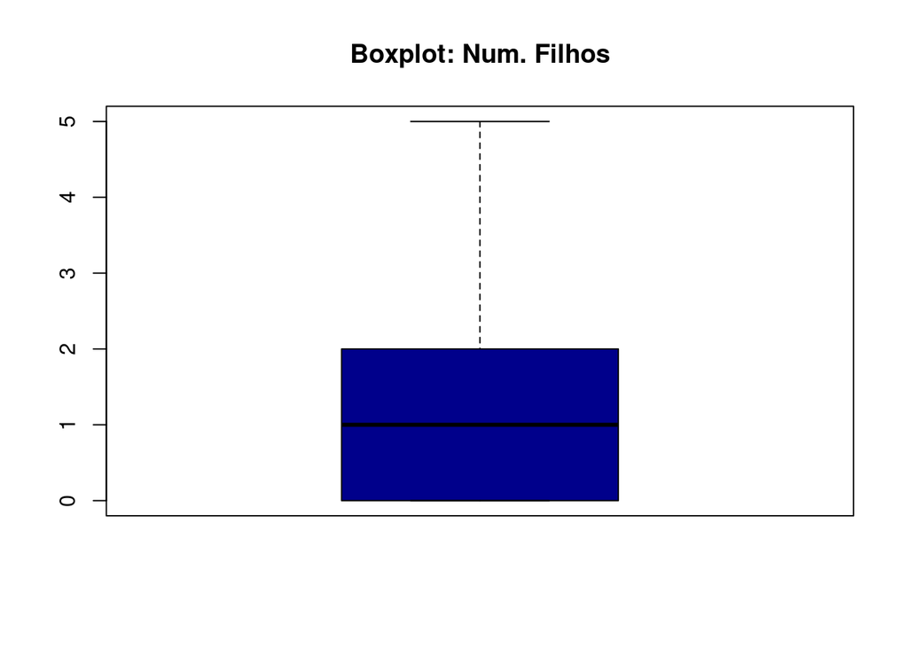

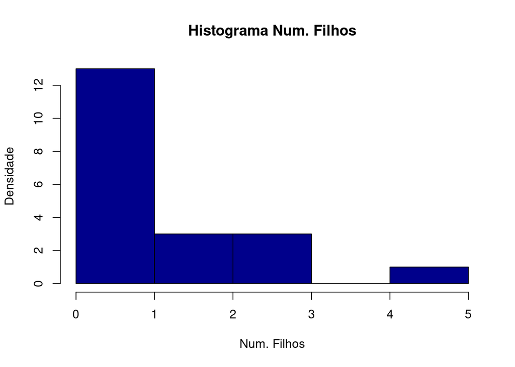

- Conjunto não é uniforme visto que 45% das pessoas não tem filhos e 20% possui apenas 1 filhos,

## Altura

Amplitude

```
## [1] 0.32
```

Média

```
## [1] 1.732
```

Quartis 1, 2 e 3 respectivamente

```
##    25%
## 1.6725
```

```
##   50%
## 1.725
```

```
##    75%
## 1.7925
```

Frequência absoluta, relativa e percentual respectivamente

```
## rolAlturas
##  1.6 1.64 1.65 1.68 1.69  1.7 1.72 1.73 1.74 1.75 1.78 1.79  1.8 1.82  1.9 1.92
##    2    1    2    2    1    1    1    1    1    1    1    1    2    1    1    1
```

```
## rolAlturas
##  1.6 1.64 1.65 1.68 1.69  1.7 1.72 1.73 1.74 1.75 1.78 1.79  1.8 1.82  1.9 1.92
## 0.10 0.05 0.10 0.10 0.05 0.05 0.05 0.05 0.05 0.05 0.05 0.05 0.10 0.05 0.05 0.05
```

```
## rolAlturas
##  1.6 1.64 1.65 1.68 1.69  1.7 1.72 1.73 1.74 1.75 1.78 1.79  1.8 1.82  1.9 1.92
##   10    5   10   10    5    5    5    5    5    5    5    5   10    5    5    5
```

Variância e Desvio Padrão respectivamente

```
## [1] 0.007985263
```

```
## [1] 0.0893603
```

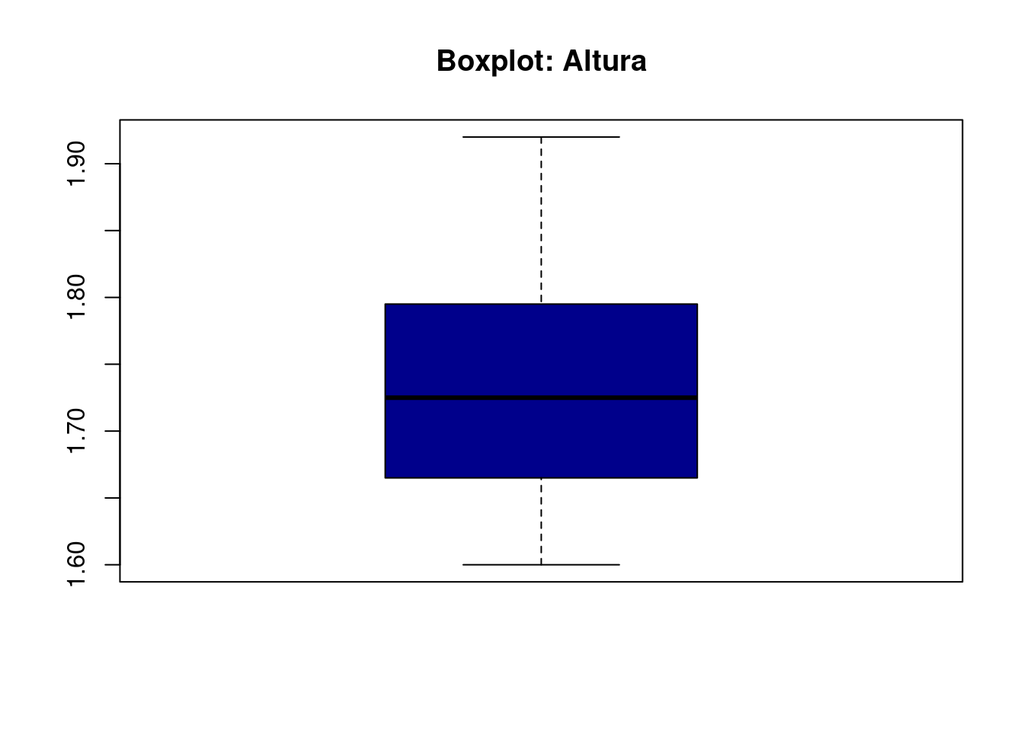

- Conjunto uniforme, com uma variância baixa o que significa que a maior parte dos valores se encontra em torno da média

## Peso

Amplitude

```
## [1] 46.5
```

Média

```
## [1] 75.43
```

Quartis 1, 2 e 3 respectivamente

```
##  25%
## 66.4
```

```
##   50%
## 75.65
```

```
##   75%
## 84.65
```

Frequência absoluta, relativa e percentual respectivamente

```
## rolPesos
##  54.2  56.4  63.9  64.2  65.5  66.7    68  72.3  72.5  75.4  75.9    80  80.9
##     1     1     1     1     1     1     1     1     1     1     1     1     1
##  81.3  84.6  84.8  85.4  85.7  90.2 100.7
##     1     1     1     1     1     1     1
```

```
## rolPesos
##  54.2  56.4  63.9  64.2  65.5  66.7    68  72.3  72.5  75.4  75.9    80  80.9
##  0.05  0.05  0.05  0.05  0.05  0.05  0.05  0.05  0.05  0.05  0.05  0.05  0.05
##  81.3  84.6  84.8  85.4  85.7  90.2 100.7
##  0.05  0.05  0.05  0.05  0.05  0.05  0.05
```

```
## rolPesos
##  54.2  56.4  63.9  64.2  65.5  66.7    68  72.3  72.5  75.4  75.9    80  80.9
##     5     5     5     5     5     5     5     5     5     5     5     5     5
##  81.3  84.6  84.8  85.4  85.7  90.2 100.7
##     5     5     5     5     5     5     5
```

Variância e Desvio Padrão respectivamente

```
## [1] 138.9096
```

```
## [1] 11.78599
```

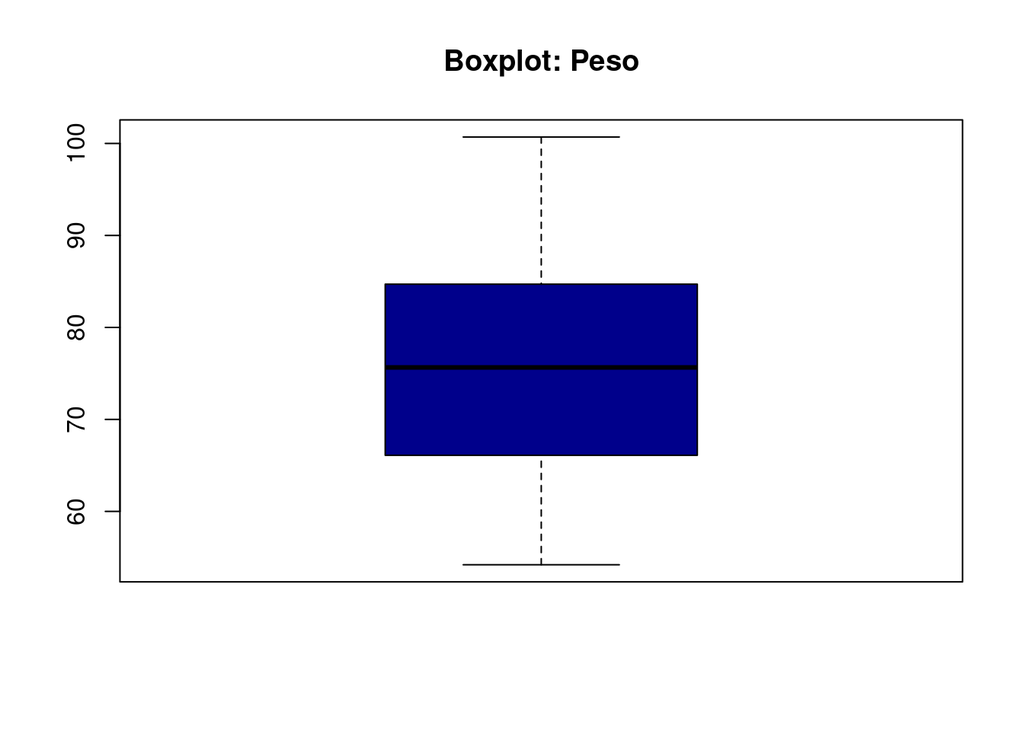

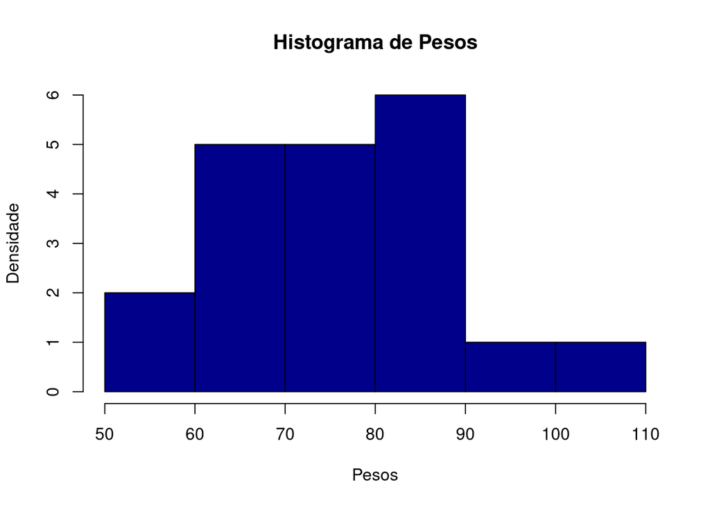

- 80% das pessoas entrevistadas se encontram no intevalo de [60, 90]

## Correlações com Gráficos de Dispersão

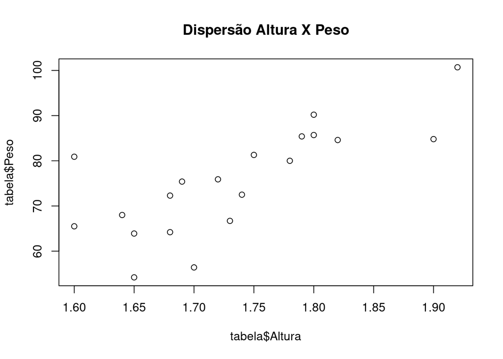

- Pode-se notar uma correlação positiva, visto que conforme a altura aumenta o peso aumenta

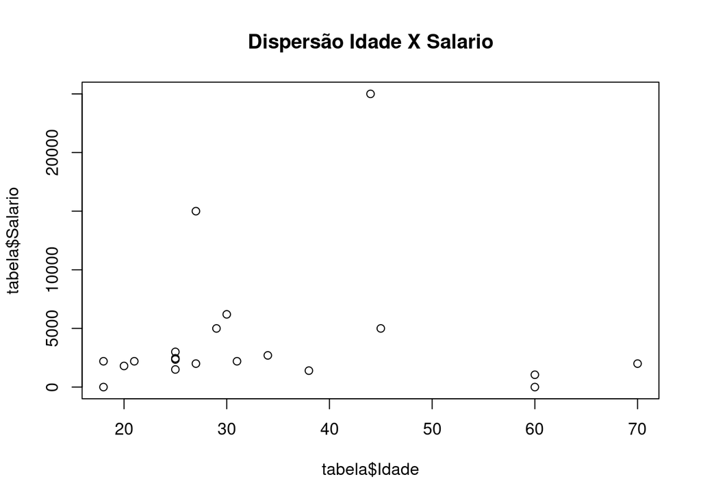

- Com base no conjunto de dados e no gráfico apresentado poderíamos concluir que a idade não tem relação com o salário

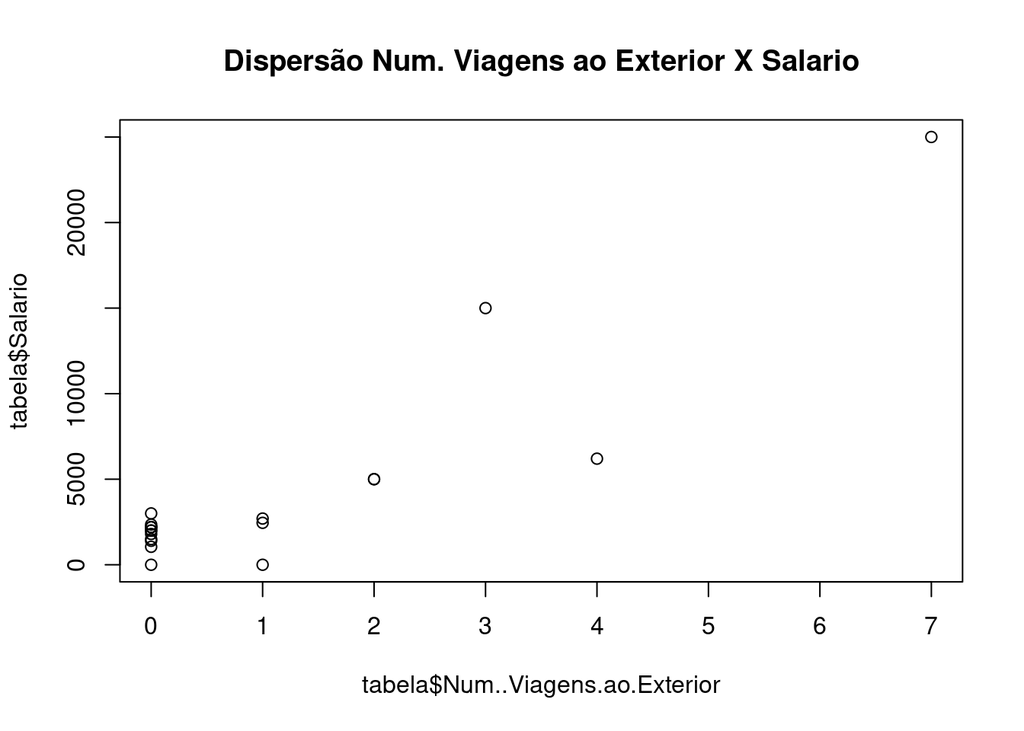